# Napoli Ballers History

Tom Gardner

August 26, 2017

## Data

For the 8th season of the Napoli Ballers Fantasy Football League, I figured I’d go back and run some numbers on the first 7 years of the league. I scraped this data from our [historical expanded standings](http://games.espn.com/ffl/tools/finalstandings?leagueId=725705&seasonId=2016). The raw data file is [here](https://github.com/twgardner2/NapoliBallers/blob/master/NapoliBallersHistory.xlsx). This is the data itself:

| year | rank | owner | w | l | tie | pf | pa | pfPerGame | paPerGame | pointDiff | draftorder | winnings |
| --- | --- | --- | --- | --- | --- | --- | --- | --- | --- | --- | --- | --- |
| 2010 | 1 | Tom Gardner | 9 | 4 | 0 | 1258 | 1119 | 96.8 | 86.1 | 10.7 | NA | NA |
| 2010 | 2 | Terrance Surbella | 9 | 4 | 0 | 1407 | 1112 | 108.2 | 85.5 | 22.7 | NA | NA |
| 2010 | 3 | Jake Granatino | 8 | 5 | 0 | 1127 | 1069 | 86.7 | 82.2 | 4.5 | NA | NA |
| 2010 | 4 | Tom Digan | 7 | 6 | 0 | 1177 | 1103 | 90.5 | 84.8 | 5.7 | NA | NA |
| 2010 | 5 | Jonathan Goerk | 6 | 7 | 0 | 1146 | 1123 | 88.2 | 86.4 | 1.8 | NA | NA |
| 2010 | 6 | John Parker | 7 | 6 | 0 | 1020 | 1044 | 78.5 | 80.3 | -1.8 | NA | NA |
| 2010 | 7 | william sheridan | 5 | 8 | 0 | 1118 | 1161 | 86.0 | 89.3 | -3.3 | NA | NA |
| 2010 | 8 | Jonathan Connelly | 6 | 7 | 0 | 1034 | 1077 | 79.5 | 82.8 | -3.3 | NA | NA |
| 2010 | 9 | Jon Kalscheuer | 4 | 9 | 0 | 977 | 1266 | 75.2 | 97.4 | -22.2 | NA | NA |
| 2010 | 10 | Jesse Burson | 4 | 9 | 0 | 1141 | 1331 | 87.8 | 102.4 | -14.6 | NA | NA |
| 2011 | 1 | Tim Lindsay | 11 | 2 | 0 | 1439 | 1230 | 110.7 | 94.6 | 16.1 | NA | NA |
| 2011 | 2 | chris lambert | 9 | 4 | 0 | 1611 | 1349 | 123.9 | 103.8 | 20.2 | NA | NA |
| 2011 | 3 | Aaron Peterson | 9 | 4 | 0 | 1561 | 1301 | 120.1 | 100.1 | 20.0 | NA | NA |
| 2011 | 4 | Tom Digan | 9 | 4 | 0 | 1462 | 1256 | 112.5 | 96.6 | 15.8 | NA | NA |
| 2011 | 5 | Jonathan Goerk | 6 | 7 | 0 | 1464 | 1533 | 112.6 | 117.9 | -5.3 | NA | NA |
| 2011 | 6 | Terrance Surbella | 6 | 6 | 1 | 1402 | 1472 | 107.8 | 113.2 | -5.4 | NA | NA |
| 2011 | 7 | Tom Gardner | 7 | 6 | 0 | 1316 | 1323 | 101.2 | 101.8 | -0.5 | NA | NA |
| 2011 | 8 | Jake Granatino | 5 | 8 | 0 | 1397 | 1531 | 107.5 | 117.8 | -10.3 | NA | NA |
| 2011 | 9 | Aaron K | 3 | 10 | 0 | 1162 | 1366 | 89.4 | 105.1 | -15.7 | NA | NA |
| 2011 | 10 | william sheridan | 5 | 8 | 0 | 1295 | 1389 | 99.6 | 106.8 | -7.2 | NA | NA |
| 2011 | 11 | Jesse Burson | 4 | 8 | 1 | 1227 | 1438 | 94.4 | 110.6 | -16.2 | NA | NA |
| 2011 | 12 | David Koeppel | 3 | 10 | 0 | 1368 | 1516 | 105.2 | 116.6 | -11.4 | NA | NA |
| 2012 | 1 | Terrance Surbella | 9 | 4 | 0 | 1412 | 1295 | 108.6 | 99.6 | 9.0 | NA | NA |
| 2012 | 2 | Tim Lindsay | 8 | 4 | 1 | 1691 | 1421 | 130.1 | 109.3 | 20.8 | NA | NA |
| 2012 | 3 | Jon Kalscheuer | 6 | 7 | 0 | 1471 | 1488 | 113.2 | 114.5 | -1.3 | NA | NA |
| 2012 | 4 | Tom Gardner | 8 | 5 | 0 | 1372 | 1354 | 105.5 | 104.2 | 1.4 | NA | NA |
| 2012 | 5 | william sheridan | 6 | 7 | 0 | 1395 | 1339 | 107.3 | 103.0 | 4.3 | NA | NA |
| 2012 | 6 | Jesse Burson | 6 | 6 | 1 | 1534 | 1419 | 118.0 | 109.2 | 8.8 | NA | NA |
| 2012 | 7 | chris lambert | 8 | 5 | 0 | 1373 | 1395 | 105.6 | 107.3 | -1.7 | NA | NA |
| 2012 | 8 | Christopher Heine | 6 | 7 | 0 | 1428 | 1481 | 109.8 | 113.9 | -4.1 | NA | NA |

[output cut: 56 more lines]

## Owners

TJ has done a good job of keeping Napoli Ballers alive since 2010 - especially since we are all spread across the globe, but I took a look at everyone who has been in the league:

| owner | count | 2010 | 2011 | 2012 | 2013 | 2014 | 2015 | 2016 | 2017 |
| --- | --- | --- | --- | --- | --- | --- | --- | --- | --- |
| Jake Granatino | 8 | X | X | X | X | X | X | X | X |
| Jesse Burson | 8 | X | X | X | X | X | X | X | X |
| Terrance Surbella | 8 | X | X | X | X | X | X | X | X |
| Tim Lindsay | 7 |  | X | X | X | X | X | X | X |
| Tom Gardner | 7 | X | X | X | X | X |  | X | X |
| Tom Digan | 6 | X | X | X |  |  | X | X | X |
| william sheridan | 6 | X | X | X |  |  | X | X | X |
| Aaron Peterson | 5 |  | X | X |  |  | X | X | X |
| Alec Emmert | 4 |  |  |  |  | X | X | X | X |
| Jonathan Goerk | 4 | X | X |  |  | X | X |  |  |
| chris lambert | 3 |  | X | X | X |  |  |  |  |
| Hans Biebl | 3 |  |  |  |  |  | X | X | X |
| Jon Kalscheuer | 3 | X |  | X | X |  |  |  |  |
| Aaron K | 2 |  | X |  |  | X |  |  |  |
| Christopher Heine | 2 |  |  | X | X |  |  |  |  |
| John Parker | 2 | X |  |  | X |  |  |  |  |
| Andrew Lawrence | 1 |  |  |  | X |  |  |  |  |
| Burnes Brown | 1 |  |  |  | X |  |  |  |  |
| David Koeppel | 1 |  | X |  |  |  |  |  |  |
| Eric Kirlin | 1 |  |  | X |  |  |  |  |  |
| John Ross | 1 |  |  |  |  |  |  |  | X |
| Jonathan Connelly | 1 | X |  |  |  |  |  |  |  |
| Maksudul Ali | 1 |  |  |  |  |  |  |  | X |
| Nicholas Woodcock | 1 |  |  |  | X |  |  |  |  |

## Medal Table

Over the course of our league, Who has had the best results?:

| owner | 1st Place | 2nd Place | 3rd Place | Wins | Losses | Ties |
| --- | --- | --- | --- | --- | --- | --- |
| Aaron Peterson | 0 | 0 | 1 | 0 | 0 | 0 |
| Alec Emmert | 0 | 0 | 1 | 0 | 0 | 0 |
| chris lambert | 0 | 1 | 1 | 23 | 16 | 0 |
| Jake Granatino | 0 | 1 | 1 | 0 | 0 | 0 |
| Jesse Burson | 0 | 1 | 1 | 0 | 0 | 0 |
| Jon Kalscheuer | 0 | 0 | 1 | 14 | 25 | 0 |
| Jonathan Goerk | 0 | 1 | 0 | 25 | 29 | 0 |
| Nicholas Woodcock | 1 | 0 | 0 | 9 | 4 | 0 |
| Terrance Surbella | 3 | 1 | 1 | 0 | 0 | 0 |
| Tim Lindsay | 1 | 1 | 0 | 0 | 0 | 0 |
| Tom Gardner | 2 | 1 | 0 | 0 | 0 | 0 |
| Aaron K | 0 | 0 | 0 | 7 | 20 | 0 |
| Andrew Lawrence | 0 | 0 | 0 | 6 | 7 | 0 |
| Burnes Brown | 0 | 0 | 0 | 3 | 10 | 0 |
| Christopher Heine | 0 | 0 | 0 | 13 | 13 | 0 |
| David Koeppel | 0 | 0 | 0 | 3 | 10 | 0 |
| Eric Kirlin | 0 | 0 | 0 | 4 | 9 | 0 |
| Hans Biebl | 0 | 0 | 0 | 0 | 0 | 0 |
| John Parker | 0 | 0 | 0 | 16 | 10 | 0 |
| John Ross | 0 | 0 | 0 | 0 | 0 | 0 |
| Jonathan Connelly | 0 | 0 | 0 | 6 | 7 | 0 |
| Maksudul Ali | 0 | 0 | 0 | 0 | 0 | 0 |
| Tom Digan | 0 | 0 | 0 | 0 | 0 | 0 |
| william sheridan | 0 | 0 | 0 | 0 | 0 | 0 |

If only I could quantify the amount of smack talk that goes on and compare it to this table (I’m looking at you, Jake).

That’s all I’ve had time to look at so far, but I’d like to add pot winnings/penalties for sucking, and a few other things to this. Maybe it would be interesting to look at draft position vs. results in a given year.

Everything below this point is just stuff I’m working on and testing out:

Test inline HTML

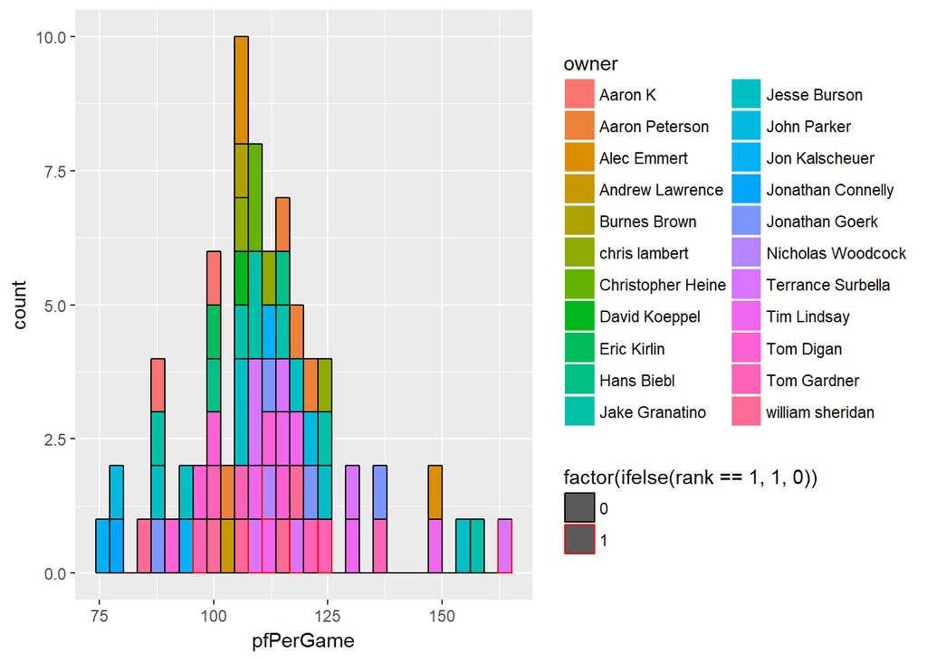